# Study 1: Power Analysis

Glenn Williams

01/11/2021

```r
# load required packages
library("lme4")        # model specification / estimation
library("afex")        # anova and deriving p-values from lmer
library("broom.mixed") # extracting data from model fits
library("faux")        # data simulation
library("tidyverse")   # data wrangling and visualisation
library("here")        # for consistent file paths across machines
library("kableExtra")  # for printing tables in rmarkdown

# ensure this script returns the same results on each run
set.seed(1892)
faux_options(verbose = FALSE)
```

```r
# functions
logit <- function(x) { log(x / (1 - x)) }
inv_logit <- function(x) { 1 / (1 + exp(-x)) }
```

# Pilot Data

## Design

### Set up

In a pilot study we explored whether the implied orientation of metaphors can influence overt behaviour in target selection. In this study, participants read a metaphor associated with anxiety or depression. Sentences were presented either in past or future tense. Crucially, fillers were included which had no association with anxiety or depression states (termed neutral emotion) and were always presented in present tense.

After reading the sentence (e.g. depression and future tense = “I will reach rock bottom.”) participants pressed a button to replace the sentence with two targets presented in the upper and lower visual field and randomly offset to the left or right of the screen. Participants were tasked with clicking one of the targets as quickly and accurately as possible. We predicted participants would click on targets in the upper visual field more often following anxiety-related metaphors and they would click on targets in the lower visual field more often following depression-related metaphors.

### Issues

Unfortunately, while neutral and present tense items were included in the design these were used only for the filler items. Thus, present tense versions of the anxiety and depression metaphors were not included and the neutral items only appeared in present tense and not past and future tense. This precludes a fully crossed design allowing us to delineate the effects of emotion and tense on clicking behaviour. As a further issue, only two targets were presented to participants after the sentences in the upper and lower visual field and with offsets to the left and right sides of the screen. Thus, if a target is in the upper visual field to the right it is unclear whether participants clicked it due to any bias in clicking up (e.g. from the emotion) or for clicking targets to the right (e.g. from tense). Thus Study 1 will address both of these issues by having a fully crossed design and including four targets; one in each quadrant of the screen. Still, since emotion is the main focus of Study 1 we will base the power analysis on this primary analysis. Tense will be analysed in terms of left and right clicks but this is secondary and thus not of primary interest in terms of the power analysis.

Due to these issues, the following analysis focuses on emotion only, but caution must be applied when interpreting the findings.

# Primary Analyses: Emotion

## Pilot Data Analysis

Of primary interest was the proportion of clicks on targets in the upward position (vs. downward position) on the screen. Here, a binary outcome represents this behaviour, captured in the clicked `clicked_up` variable whereby a 1 indicates participants clicked up and a 0 indicates they did not. On a trial by trial basis with a binomial outcome the data can be appropriately modelled using a generalised linear mixed model with a logit link function. This ensures that the model does not make predictions beyond the bounds of the data (i.e. proportions of clicks below 0 or above 1). The coefficients from a logit mixed model represents probability in the log-odds space. A demonstration of how the two are related is shown below.

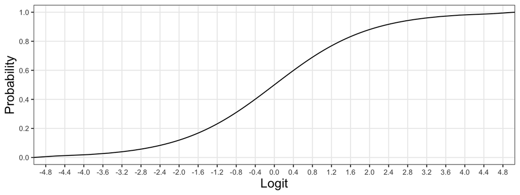

```r
data.frame(prob = seq(0, 1, .01)) %>%
  mutate(logit = logit(prob)) %>%
  ggplot(aes(x = logit, y = prob)) +
  geom_line() +
  scale_x_continuous(breaks = seq(-6, 6, by = 0.4)) +
  scale_y_continuous(breaks = seq(0, 1, by = 0.2)) +
  theme_bw() +
  labs(x = "Logit", y = "Probability") +
  theme(
    axis.title = element_text(size = 14),
    axis.text = element_text(size = 8),
    panel.grid.minor = element_blank()
  )
```

To get a representative estimate of the parameters needed for a power analysis, we first analysed the pilot data. We used a generalised linear mixed effects model with a logit link function and with a fixed effect of emotion. Emotion was treatment coded such that the intercept represents the neutral condition, and the two slope terms represent the difference between the neutral condition and the anxiety and depression conditions respectively. The model used a maximal random effects structure (Barr et al., 2013). Namely, it contained a random intercept and slope of emotion for each participant as participants see each condition throughout the study, and a random intercept for item since each item can only represent a single condition.

Crucially, the fixed effects parameter estimates report *p*-values testing against the null (i.e. a score on log-odds of zero) for the neutral condition. On the probability space this means that the coefficient is tested against being a probability of 50%, or an equal chance of clicking up or down ($logit(.50) = 0$). This ensures a test indicating whether or not the neutral condition shows any bias in clicks towards any direction. The two slope terms then test against whether the difference between the neutral and anxiety, and neutral and depression conditions is 0; i.e. whether the emotion metaphors bias clicks upwards or downwards relative to the neutral items.

```r
data_pilot <- read_csv(here("02_data", "00_pilot", "02_cleaned", "cleaned_data_r.csv")) %>%
  mutate(
    participant = as.factor(participant),
    item = as.factor(item),
    emotion = factor(
      emotion,
      levels = c("neutral", "anxiety", "depression"),
      labels = c("neutral", "anxiety", "depression")
    ),
    tense = factor(
      tense,
      levels = c("present", "past", "future"),
      labels = c("present", "past", "future")
    )
  )

# treatment code contrasts for variables of interest
contrasts(data_pilot$emotion) <- contr.treatment(3) # neutral = intercept
contrasts(data_pilot$tense) <- contr.treatment(3) # present = intercept
```

As emotion is within-subjects (participants see all emotions) and between-items (items are neutral, anxiety-related, depression-related) the model uses a fixed effect of emotion, a random intercept and slope of emotion by participants (including their correlation), and a random intercept by item. The full model results are shown below.

```r
pilot_emotion_mod_filename <- here(
  "03_analysis",
  "01_study-one",
  "01_power-analysis",
  "pilot_emotion_mod.rds"
)

if (!file.exists(pilot_emotion_mod_filename)) {

  # run model and save to a file
  mod_emotion_pilot <- lme4::glmer(
    clicked_up ~ emotion +
      (1 + emotion | participant) + (1 | item),
    data = data_pilot,
    family = binomial(link = "logit")
  )

  write_rds(mod_emotion_pilot, pilot_emotion_mod_filename)
}

if(file.exists(pilot_emotion_mod_filename)) {
  mod_emotion_pilot <- read_rds(pilot_emotion_mod_filename)
}

summary(mod_emotion_pilot)
```

```
## Generalized linear mixed model fit by maximum likelihood (Laplace
##   Approximation) [glmerMod]
##  Family: binomial  ( logit )
## Formula: clicked_up ~ emotion + (1 + emotion | participant) + (1 | item)
##    Data: data_pilot
##
##      AIC      BIC   logLik deviance df.resid
##   5347.3   5411.8  -2663.6   5327.3     4646
##
## Scaled residuals:
##     Min      1Q  Median      3Q     Max
## -4.7589 -0.7779  0.2403  0.7189  3.6078
##
## Random effects:
##  Groups      Name        Variance Std.Dev. Corr
##  participant (Intercept) 1.0455   1.0225
##              emotion2    0.1517   0.3894    0.05
##              emotion3    2.3775   1.5419    0.22 -0.17
##  item        (Intercept) 0.1747   0.4179
## Number of obs: 4656, groups:  participant, 97; item, 48
##
## Fixed effects:
##             Estimate Std. Error z value Pr(>|z|)
## (Intercept)   0.5408     0.1589   3.403 0.000667 ***
## emotion2      0.2341     0.1757   1.332 0.182872
## emotion3     -1.2619     0.2363  -5.339 9.34e-08 ***
## ---
## Signif. codes:  0 '***' 0.001 '**' 0.01 '*' 0.05 '.' 0.1 ' ' 1
##
## Correlation of Fixed Effects:
##          (Intr) emotn2
## emotion2 -0.506
## emotion3 -0.286  0.320
```

With 97 participants and 48 items we found a significant effect for the intercept; the neutral condition tested against a log odds of 0. This shows that for the neutral condition the proportion of upward clicks deviated from chance with more up clicks than expected by chance. We found no significant effect for the difference between the neutral and anxiety conditions. Finally, we found a significant effect for the difference between the neutral and depression condition whereby participants were less likely to click up (and therefore more likely to click down) in the depression condition. The results are also shown with the probability of clicking up below (see the `prob` column).

```r
pilot_emotion_est <- broom.mixed::tidy(mod_emotion_pilot)

pilot_emotion_int_est <- filter(pilot_emotion_est, is.na(group), term == "(Intercept)") %>%
  pull(estimate)
pilot_emotion_cat_est_1 <- filter(pilot_emotion_est, is.na(group), term == "emotion2") %>%
  pull(estimate)
pilot_emotion_cat_est_2 <- filter(pilot_emotion_est, is.na(group), term == "emotion3") %>%
  pull(estimate)

pilot_pr0 <- inv_logit(pilot_emotion_int_est) %>% round(2)
pilot_pr1_plus <- inv_logit(pilot_emotion_int_est + pilot_emotion_cat_est_1) %>% round(2)
pilot_pr2_plus <- inv_logit(pilot_emotion_int_est + pilot_emotion_cat_est_2) %>% round(2)

pilot_emotion_est <- pilot_emotion_est %>%
  arrange(!is.na(group), group, term) %>%
  mutate(
  prob = c(pilot_pr0, pilot_pr1_plus, pilot_pr2_plus, rep(NA, 7))
) %>%
  mutate_if(is.numeric, round, 2) %>%
  select(effect:estimate, prob, everything())

# print it
kable(pilot_emotion_est) %>%
  kable_classic()
```

| effect | group | term | estimate | prob | std.error | statistic | p.value |
| --- | --- | --- | --- | --- | --- | --- | --- |
| fixed | NA | (Intercept) | 0.54 | 0.63 | 0.16 | 3.40 | 0.00 |
| fixed | NA | emotion2 | 0.23 | 0.68 | 0.18 | 1.33 | 0.18 |
| fixed | NA | emotion3 | -1.26 | 0.33 | 0.24 | -5.34 | 0.00 |
| ran_pars | item | sd__(Intercept) | 0.42 | NA | NA | NA | NA |
| ran_pars | participant | cor__(Intercept).emotion2 | 0.05 | NA | NA | NA | NA |
| ran_pars | participant | cor__(Intercept).emotion3 | 0.22 | NA | NA | NA | NA |
| ran_pars | participant | cor__emotion2.emotion3 | -0.17 | NA | NA | NA | NA |
| ran_pars | participant | sd__(Intercept) | 1.02 | NA | NA | NA | NA |
| ran_pars | participant | sd__emotion2 | 0.39 | NA | NA | NA | NA |
| ran_pars | participant | sd__emotion3 | 1.54 | NA | NA | NA | NA |

Using this as a baseline, we might expect strong effects wherey depression metaphors bias participants to click up less often when compared to neutral items. There is some evidence for anxiety items being associated with more up clicks than neutral items, although this effect is small and non-significant. There is evidence that neutral items are associated with more up clicks than expected by chance. This however may be due to issues in the design of the neutral items whereby emotions other than anxiety and depression could be present in the items, potentially biasing clicking behaviour.

# Study 1

## Primary Analyses: Emotion

### Design and Modelling

Our power analysis was based on a design with assumptions as follows:

Emotion is a within-participant but between-item factor with 3 levels; neutral, anxiety, depression. Thus the model will predict up clicks using a generalised linear mixed effects model (using a logit link function) with a fixed effect of emotion and random intercepts and slopes of emotion by participant (including their correlation). Random intercepts will also be included for item. The default “bobyqa” optimiser with default control parameters will be used.

### Parameter Estimates

Using treatment coding with the neutral condition as the baseline we assume that the intercept will have a fixed effect beta on the logit scale of 0 (i.e. a probability of .50 for clicking up). We will assume that participants are at least 1.6 times more likely to click up in the anxiety condition, i.e. approximately twice that observed in the pilot. This estimate is larger than the effect found in the pilot study simply because we still expect anxiety items to cause more up clicks, but we expect now that neutral items will have up clicks that align with chance clicking behaviour. Any effects below this cutoff we assume to be approximately zero, hence this is our smallest effect size of interest. Thus, the fixed effect for this condition is log(1.6) or 0.47 on the logit scale.

We assume that the fixed effect of the depression condition is at least log(2) or 0.69 on the logit scale, approximately half that observed in the pilot study. This prediction is made as the pilot study showed particularly strong effects for the depression items which may be unrealistically large, for example due to a type-M error.

We will settle on a participant and item sample size when at least 90% of the simulations show significant effects for the anxiety and depression slope parameter estimates. Additionally, as we predict that the neutral condition will show a non-significant effect (i.e. no deviation from chance) this initial power analysis will give us the probability of a false-positive. We will find this analysis appropriate only when around 5% of simulations show a significant effect for the intercept (given some error).

While showing that clicking behaviour is due to chance with the neutral items is part of our predictions, this is not key to our hypotheses. Indeed, as long as anxiety and depression items reliably differ from the neutral items we will deem our hypotheses as being corroborated regardless of the baseline upwards clicks for the neutral items. However, for completeness and to test the secondary prediction that clicking behaviour should be due to chance for the neutral items we will perform an equivalence test for both the power analysis and the final analyis in the study. Details of the lower and upper bounds and how this is implemented for a mixed effect model follow after the main power analysis.

When interpreting the fixed effect estimates it is important to realise that the anxiety and depression effects are relative to the neutral effect. This is depicted below across a range of logits. Where the neutral condition has more extreme values (i.e. further from 0), differences between the neutral condition relative to the anxiety and depression conditions is decreased.

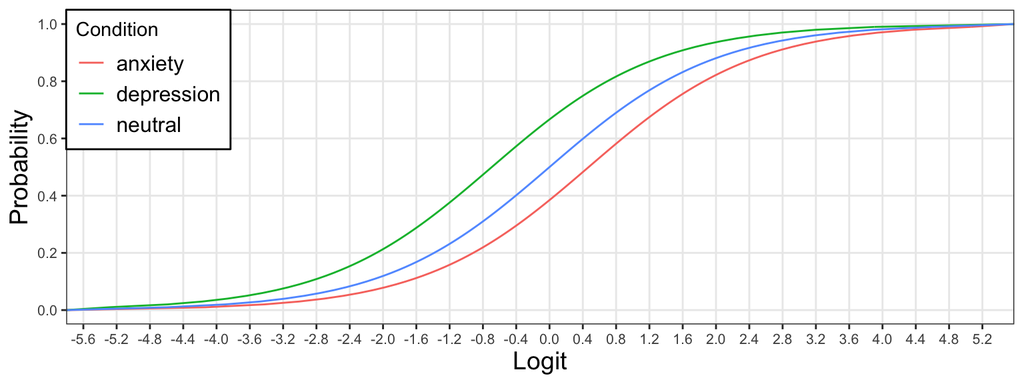

```r
data.frame(prob = seq(0, 1, .01)) %>%
  mutate(
    neutral = logit(prob),
    anxiety = neutral + log(1.6),
    depression = neutral - log(2)
  ) %>%
  pivot_longer(
    cols = c(neutral, anxiety, depression),
    names_to = "condition",
    values_to = "logit"
  ) %>%
  ggplot(aes(x = logit, y = prob, colour = condition)) +
  geom_line() +
  scale_x_continuous(breaks = seq(-6, 6, by = 0.4)) +
  scale_y_continuous(breaks = seq(0, 1, by = 0.2)) +
  theme_bw() +
  labs(x = "Logit", y = "Probability", colour = "Condition") +
  theme(
    axis.title = element_text(size = 14),
    axis.text = element_text(size = 8),
    panel.grid.minor = element_blank(),
    legend.text = element_text(size = 12),
    legend.position = c(0, 1),
    legend.justification = c(0, 1),
    legend.background = element_rect(
      linetype = "solid",
      colour = "black"
    )
  )
```

Details of the remaining parameter estimates are provided below and are largely estimated from the pilot study with standard deviations rounded up under the assumption that the pilot study may underestimate the magnitude of any variability in scores.

```r
# set up the custom data simulation function
simulate_binary_data <- function(
  n_subj         = 105, # number of subjects
  n_intercept    = 30,  # number of neutral items
  n_slope_1      = 30,  # number of anxiety items
  n_slope_2      = 30,  # number of depression items
  beta_0         = 0, # intercept (mean of means)
  beta_1         = log(1.6), # effect of anxiety (vs grand mean); 1.6 times more likely to click up
  beta_2         = -log(2), # effect of depression (vs grand mean); 2 times more likely to click down
  omega_0        = 0.5, # by-item random intercept sd
  tau_0          = 1, # by-subject random intercept sd
  tau_1          = 0.5, # by-subject random slope sd for beta_1
  tau_2          = 1.5, # by-subject random slope sd for beta_2
  rho_1          = 0, # correlation between intercept and slope for beta_1
  rho_2          = 0.2, # correlation between intercept and slope for beta_2
  rho_3          = -0.2 # correlation between beta_1 and beta_2
                        ) {
   # simulate a sample of items
  items <- data.frame(
    item_id = 1:(n_intercept + n_slope_1 + n_slope_2),
    condition = rep(
      c("intercept", "slope_1", "slope_2"),
      c(n_intercept + n_slope_1 + n_slope_2)
    ),
    O_0i = rnorm(n_intercept + n_slope_1 + n_slope_2, 0, omega_0)
  )

  # effect code category
  items$X_1 <- recode(
    items$condition,
    "intercept" = 0,
    "slope_1" = 1,
    "slope_2" = 0
  )

  items$X_2 <- recode(
    items$condition,
    "intercept" = 0,
    "slope_1" = 0,
    "slope_2" = 1
  )

  # simulate a sample of subjects
  subjects <- faux::rnorm_multi(
    n = n_subj,
    mu = 0,
    sd = c(tau_0, tau_1, tau_2),
    r = c(rho_1, rho_2, rho_3),
    varnames = c("T_0s", "T_1s", "T_2s")
  )
  subjects$subj_id <- 1:n_subj

  # cross subject and item IDs
  crossing(subjects, items)  %>%
    mutate(
      # calculate gaussian DV
      Y = beta_0 + T_0s + O_0i + (beta_1 + T_1s)*X_1 + (beta_2 + T_2s)*X_2,
      pr = inv_logit(Y), # transform to probability of getting 1
      Y_bin = rbinom(nrow(.), 1, pr) # sample from bernoulli distribution
    ) %>%
    select(subj_id, item_id, condition, X_1, X_2, Y, Y_bin)
}
```

### Power Function

With the data generation process and model fitting methods defined, we performed the power analysis using the following function.

```r
# simulate data and fit model
single_run <- function(filename = NULL, ...) {
  # ... is a shortcut that forwards any arguments to my_sim_data()
  dat_sim <- simulate_binary_data(...)
  mod_sim <- glmer(
    Y_bin ~ 1 + X_1 + X_2 +
      (1 + X_1 + X_2 | subj_id) + (1 | item_id),
    data = dat_sim,
    family = binomial(link = "logit")
  )

  sim_results <- broom.mixed::tidy(mod_sim)

  # append the results to a file if filename is set
  if (!is.null(filename)) {
    append <- file.exists(filename) # append if the file exists
    write_csv(sim_results, filename, append = append)
  }

  # return the tidy table
  sim_results
}
```

The data simulation and model fitting process was carried out using the above parameter estimates and performed 1000 times. We then evaluate the proportion of simulations that provide significant effects for the anxiety and depression terms, aiming for at least 90% of simulations to return a significant effect for both terms, thus ensuring at least 90% power for the study.

```r
# run simulations and save to a file on each rep
emotion_filename <- here(
  "03_analysis",
  "01_study-one",
  "01_power-analysis",
  "emotion_simulations.csv"
)

emotion_parameters <- list(
  reps = 1e3, # 1000 iterations
  beta_0 = 0, # intercept (neutral)
  beta_1 = log(1.6), # slope 1 (anxiety)
  beta_2 = -log(2), # slope 2 (depression)
  n_subj = 105, # initially 102
  n_intercept = 30, # neutral
  n_slope_1 = 30, # anxiety
  n_slope_2 = 30, # depression
  omega_0 = 0.5, # by-item random intercept sd
  tau_0 = 1, # by-subject random intercept sd
  tau_1 = 0.5, # by-subject random slope sd for beta_1
  tau_2 = 1.5, # by-subject random slope sd for beta_2
  rho_1 = 0, # correlation between intercept and slope for beta_1
  rho_2 = 0.2, # correlation between intercept and slope for beta_2
  rho_3 = -0.2 # correlation between beta_1 and beta_2
)

# all parameters set to the function's defaults so not passed to the function
if (!file.exists(emotion_filename)) {
  # run simulations and save to a file
  emotion_sims <- purrr::map_df(1:reps, ~single_run(
    filename = emotion_filename
    )
  )
}

# read saved simulation data
ct <- cols(# makes sure plots display in this order
  group = col_factor(ordered = TRUE),
  term = col_factor(ordered = TRUE)
)
emotion_sims <- read_csv(emotion_filename, col_types = ct)
```

### Mean Estimates and Cell Probabilities

The estimates for the simulation are as follows.

```r
# get means of parameter estimates from simulations
mean_est <- function(tidied_sims, params, rounding = 2) {

  # make mean estimates
  est <- tidied_sims %>%
    group_by(group, term) %>%
    summarise(
      mean_estimate = mean(estimate),
      mean_se = mean(std.error),
      mean_statistic = mean(abs(statistic)),
      prop_sig = mean(p.value < .05),
      .groups = "drop"
    )

  # determine probabilities for intercept and slopes
  int_est <- filter(est, term == "(Intercept)") %>%
    pull(mean_estimate)
  cat_est_1 <- filter(est, term == "X_1") %>%
    pull(mean_estimate)
  cat_est_2 <- filter(est, term == "X_2") %>%
    pull(mean_estimate)

  # add probabilities to the summary
  est %>%
    arrange(!is.na(group), group, term) %>%
    mutate(
      sim = c(
        params[["beta_0"]],
        params[["beta_1"]],
        params[["beta_2"]],
        params[["tau_0"]],
        params[["rho_1"]],
        params[["rho_2"]],
        params[["tau_1"]],
        params[["rho_3"]],
        params[["tau_2"]],
        params[["omega_0"]]
      ),
      prob = case_when(
        term == "(Intercept)" ~ inv_logit(int_est),
        term == "X_1" ~ inv_logit(int_est + cat_est_1),
        term == "X_2" ~ inv_logit(int_est + cat_est_2),
        TRUE ~ NA_real_
      )
    ) %>%
    mutate_if(is.numeric, round, 2) %>%
    select(group, term, sim, mean_estimate, mean_se, prob, everything()) %>%
    rename(set_parameter = sim)
}

# make mean estimates
emotion_est <- mean_est(emotion_sims, emotion_parameters)

# print it
kable(emotion_est) %>%
  kable_classic()
```

| group | term | set_parameter | mean_estimate | mean_se | prob | mean_statistic | prop_sig |
| --- | --- | --- | --- | --- | --- | --- | --- |
| NA | (Intercept) | 0.00 | 0.00 | 0.14 | 0.50 | 0.78 | 0.06 |
| NA | X_1 | 0.47 | 0.48 | 0.15 | 0.62 | 3.24 | 0.90 |
| NA | X_2 | -0.69 | -0.69 | 0.20 | 0.33 | 3.36 | 0.92 |
| subj_id | sd__(Intercept) | 1.00 | 0.99 | NA | NA | NA | NA |
| subj_id | cor__(Intercept).X_1 | 0.00 | 0.01 | NA | NA | NA | NA |
| subj_id | cor__(Intercept).X_2 | 0.20 | 0.20 | NA | NA | NA | NA |
| subj_id | sd__X_1 | 0.50 | 0.48 | NA | NA | NA | NA |
| subj_id | cor__X_1.X_2 | -0.20 | -0.22 | NA | NA | NA | NA |
| subj_id | sd__X_2 | 1.50 | 1.48 | NA | NA | NA | NA |
| item_id | sd__(Intercept) | 0.50 | 0.49 | NA | NA | NA | NA |

### Equivalence Testing

To evaluate evidence in support of the null hypothesis, i.e. of an effect being practically equivalent to zero, we perform equivalence tests on the model parameter estimates. This requires establishing a region of practical equivalence, which we set as between a score of -log(1.6) and log(1.6) (approximately -0.47 and 0.47) on the logit scale. This is selected as the study is powered to detect an effect in the anxiety condition of at least log(1.6) on the logit scale. Thus, because the power analysis assumes this is the minimally interesting effect size we set our region of practical equivalence to be anything below this size in either direction. Using this as our region of practical equivalence we used the two one-sided test (TOST) method and determined the proportion of our simulations whereby the neutral condition’s paraemter estimate is practically equivalent to zero. The proportion of simulations showing a statistically equivalent finding for the intercept and slope terms is shown below.

```r
test_equivalence <- function(
  tidied_model,
  bound_lower = -log(1.6),
  bound_upper = log(1.6),
  average = TRUE
  ) {
  # bounds defaults to +- log(1.6),
  # or 1.6 times less more/likely to give a response
  # this is approximately +- 0.47 logits,
  # this variest on the probability scale,
  # but assuming 50% change to give a response
  # this equates to bounds of 0.38 and 0.62.

  # filter to fixed effects only
  fixed_effects <- filter(tidied_model, effect == "fixed")

  # calcualte 90% Wald CIs and add to df
  fixed_effects$ci_lower <- fixed_effects$estimate -
    fixed_effects$std.error*qnorm(0.95)
  fixed_effects$ci_upper <- fixed_effects$estimate +
    fixed_effects$std.error*qnorm(0.95)

  # add bounds to the df
  fixed_effects$bound_lower <- bound_lower
  fixed_effects$bound_upper <- bound_upper

  # make z-scores and p-values for the estimate against each bound
  fixed_effects$z_lower <- (fixed_effects$estimate - fixed_effects$bound_lower)/
    fixed_effects$std.error
  fixed_effects$z_upper <- (fixed_effects$estimate - fixed_effects$bound_upper)/
    fixed_effects$std.error
  fixed_effects$p_lower <- pnorm(fixed_effects$z_lower, lower.tail = FALSE)
  fixed_effects$p_upper <- pnorm(fixed_effects$z_upper, lower.tail = TRUE)

  # make equivalence test z-scores and p-values
  fixed_effects <- fixed_effects %>%
    rowwise() %>%
      mutate(
        z_quiv = ifelse(abs(z_lower) < abs(z_upper), z_lower, z_upper),
        p_equiv = max(p_lower, p_upper)
      ) %>%
    select(-group)

  if(average == TRUE) {
    # returns averages from equivlanece tests
    # (e.g. from many tests from simulation)
    fixed_effects %>%
      group_by(term) %>%
      summarise(
        mean_est = mean(estimate),
        mean_ci_lower = mean(ci_lower),
        mean_ci_upper = mean(ci_upper),
        bound_lower = mean(bound_lower),
        bound_upper = mean(bound_upper),
        prop_p_equiv = mean(p_equiv < .05),
        .groups = "drop"
      ) %>%
      mutate_if(is.numeric, round, 2)
  } else {
    # returns the equivalence test
    fixed_effects
  }
}

emotion_equiv_summary <- test_equivalence(emotion_sims)
emotion_equiv_summary %>%
  kable() %>%
  kable_classic()
```

| term | mean_est | mean_ci_lower | mean_ci_upper | bound_lower | bound_upper | prop_p_equiv |
| --- | --- | --- | --- | --- | --- | --- |
| (Intercept) | 0.00 | -0.23 | 0.23 | -0.47 | 0.47 | 0.92 |
| X_1 | 0.48 | 0.23 | 0.72 | -0.47 | 0.47 | 0.05 |
| X_2 | -0.69 | -1.02 | -0.35 | -0.47 | 0.47 | 0.00 |

Overall, under these assumptions our study is adequately powered to detect effects for the anxiety and depression conditions and to find the neutral condition to be statistically equivalent to zero.

## Secondary Analyses: Tense

```r
pilot_tense_mod_filename <- here(
  "03_analysis",
  "01_study-one",
  "01_power-analysis",
  "pilot_tense_mod.rds"
)

if (!file.exists(pilot_tense_mod_filename)) {

  # run model and save to a file
  mod_tense_pilot <- afex::mixed(
    clicked_right ~ tense +
      (1 + tense || participant) +
      (1 | item),
    data = data_pilot,
    family = binomial(link = "logit"),
    expand_re = TRUE,
    method = "LRT",
    return = "merMod",
    check_contrasts = FALSE
  )

  write_rds(mod_tense_pilot, pilot_tense_mod_filename)
}

if(file.exists(pilot_tense_mod_filename)) {
  mod_tense_pilot <- read_rds(pilot_tense_mod_filename)
}

summary(mod_tense_pilot)
```

```
## Generalized linear mixed model fit by maximum likelihood (Laplace
##   Approximation) [glmerMod]
##  Family: binomial  ( logit )
## Formula:
## clicked_right ~ tense + (1 + re1.tense2 + re1.tense3 || participant) +
##     (1 | item)
##    Data: data
##
##      AIC      BIC   logLik deviance df.resid
##   6064.6   6109.7  -3025.3   6050.6     4649
##
## Scaled residuals:
##     Min      1Q  Median      3Q     Max
## -2.6981 -0.8445 -0.4676  0.8841  2.5563
##
## Random effects:
##  Groups        Name        Variance Std.Dev.
##  participant   (Intercept) 0.15468  0.3933
##  participant.1 re1.tense2  0.23584  0.4856
##  participant.2 re1.tense3  0.71831  0.8475
##  item          (Intercept) 0.07154  0.2675
## Number of obs: 4656, groups:  participant, 97; item, 48
##
## Fixed effects:
##             Estimate Std. Error z value Pr(>|z|)
## (Intercept) -0.02820    0.09386  -0.300    0.764
## tense2      -0.60048    0.12271  -4.894 9.91e-07 ***
## tense3       0.61822    0.14227   4.345 1.39e-05 ***
## ---
## Signif. codes:  0 '***' 0.001 '**' 0.01 '*' 0.05 '.' 0.1 ' ' 1
##
## Correlation of Fixed Effects:
##        (Intr) tense2
## tense2 -0.626
## tense3 -0.540  0.541
```

## Secondary Analyses: Tense

### Design and Modelling

Our power analysis was based on a design with assumptions as follows: